# Advanced Regression Techniques using Random Forest and XGBoost

```python
import datetime
now = datetime.datetime.now()
day_month_year = '{}-{}-{} \t\t\t\t\t\t\t\t\t       By: Richard.W'.format(now.year,now.month, now.day)
print('Date:', day_month_year)
```

```
Date: 2019-8-5 									       By: Richard.W
```

```python
import pandas as pd
import numpy as np
import matplotlib.pyplot as plt
import matplotlib
import seaborn as sns
from scipy import stats
import pylab as pl
from collections import Counter
import xgboost as XGB
%matplotlib inline
```

```python
train = pd.read_csv("train.csv",index_col='Id')
test = pd.read_csv("test.csv",index_col='Id')
test_index=test.index
train.reset_index(drop=True,inplace=True)
test.reset_index(drop=True,inplace=True)
```

### We need to predict the SalePrice so lets take a look at this value

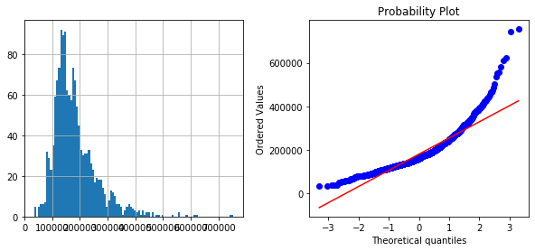

```python
plt.figure(figsize=(10,4))
plt.subplot(1, 2, 1)
train.SalePrice.hist(bins=100)

plt.subplot(1, 2, 2)
stats.probplot(train['SalePrice'], plot=plt)

plt.subplots_adjust(wspace=0.3)
```

#### We can see the SalesPrice resembels a log normal distribution: Thus, if the random variable X is log-normally distributed, then Y = ln(X) has a normal distribution.[Wiki]

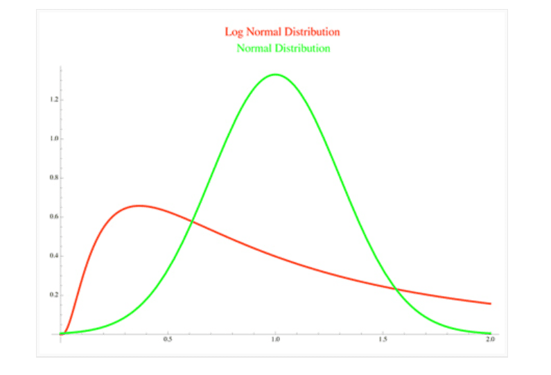

#### Because of this we will do a log transform on SalePrice

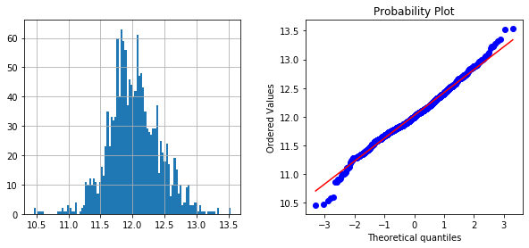

```python
plt.figure(figsize=(10,4))
plt.subplot(1, 2, 1)
np.log1p(train.SalePrice).hist(bins=100)

plt.subplot(1, 2, 2)
stats.probplot(np.log1p(train['SalePrice']), plot=plt)

plt.subplots_adjust(wspace=0.3)
```

```python
train.info()
```

```
<class 'pandas.core.frame.DataFrame'>
RangeIndex: 1460 entries, 0 to 1459
Data columns (total 80 columns):
MSSubClass       1460 non-null int64
MSZoning         1460 non-null object
LotFrontage      1201 non-null float64
LotArea          1460 non-null int64
Street           1460 non-null object
Alley            91 non-null object
LotShape         1460 non-null object
LandContour      1460 non-null object
Utilities        1460 non-null object
LotConfig        1460 non-null object
LandSlope        1460 non-null object
Neighborhood     1460 non-null object
Condition1       1460 non-null object
Condition2       1460 non-null object
BldgType         1460 non-null object
HouseStyle       1460 non-null object
OverallQual      1460 non-null int64
OverallCond      1460 non-null int64
YearBuilt        1460 non-null int64
YearRemodAdd     1460 non-null int64
RoofStyle        1460 non-null object
RoofMatl         1460 non-null object
Exterior1st      1460 non-null object
Exterior2nd      1460 non-null object
MasVnrType       1452 non-null object
MasVnrArea       1452 non-null float64
ExterQual        1460 non-null object
ExterCond        1460 non-null object
Foundation       1460 non-null object
BsmtQual         1423 non-null object
BsmtCond         1423 non-null object
BsmtExposure     1422 non-null object
BsmtFinType1     1423 non-null object
BsmtFinSF1       1460 non-null int64
BsmtFinType2     1422 non-null object
BsmtFinSF2       1460 non-null int64
BsmtUnfSF        1460 non-null int64
```

[output cut: 30 more lines]

```
EnclosedPorch    1460 non-null int64
3SsnPorch        1460 non-null int64
ScreenPorch      1460 non-null int64
PoolArea         1460 non-null int64
PoolQC           7 non-null object
Fence            281 non-null object
MiscFeature      54 non-null object
MiscVal          1460 non-null int64
MoSold           1460 non-null int64
YrSold           1460 non-null int64
SaleType         1460 non-null object
SaleCondition    1460 non-null object
SalePrice        1460 non-null int64
dtypes: float64(3), int64(34), object(43)
memory usage: 912.6+ KB
```

### Some values are stored as ints when they represent a catagorical variable we will change those to strings

```python
#some values are stored as ints when they represent a catagorical variable
#MSSubclass
train['MSSubClass']=train['MSSubClass'].apply(str)
test['MSSubClass']=test['MSSubClass'].apply(str)

#YrSold
train['YrSold']=train['YrSold'].apply(str)
test['YrSold']=test['YrSold'].apply(str)

#Mosold
train['MoSold']=train['MoSold'].apply(str)
test['MoSold']=test['MoSold'].apply(str)
```

```python
print('train has {} missing values'.format(train.isna().sum().sum()))
print('test has {} missing values'.format(test.isna().sum().sum()))
#'{}-{}-{} '.format(now.year,now.month, now.day)
```

```
train has 6965 missing values
test has 7000 missing values
```

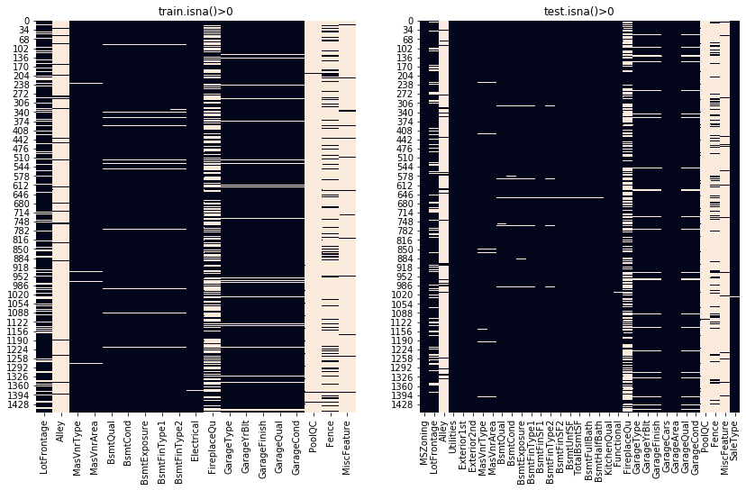

```python
plt.figure(figsize=(14,8))
plt.subplot(1, 2, 1)
sns.heatmap(train[train.columns[train.isnull().sum()>0]].isnull(),cbar=False).set_title('train.isna()>0')

plt.subplot(1, 2, 2)
sns.heatmap(test[test.columns[test.isnull().sum()>0]].isnull(),cbar=False).set_title('test.isna()>0')

plt.subplots_adjust(wspace=0.2)
```

## Lets make this a bit easier to read

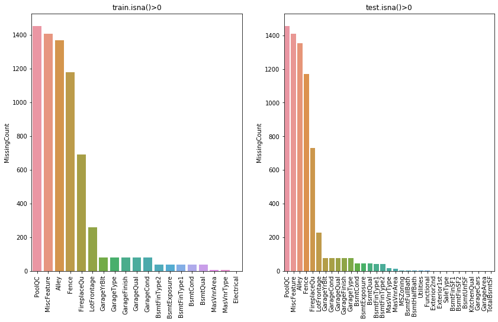

```python
plt.figure(figsize=(14,8))
plt.subplot(1, 2, 1)
Missing1=train[train.columns[train.isnull().sum()>0]].isnull().sum().sort_values(ascending=False).to_frame()
Missing1.columns = ['MissingCount']
Missing1['MissingCount']
p1=sns.barplot(x=Missing1.index, y='MissingCount', data=Missing1)
p1.set_xticklabels(p1.get_xticklabels(), rotation=90)
p1.set_title('train.isna()>0')

plt.subplot(1, 2, 2)
Missing2=test[test.columns[test.isnull().sum()>0]].isnull().sum().sort_values(ascending=False).to_frame()
Missing2.columns = ['MissingCount']
Missing2['MissingCount']
p2=sns.barplot(x=Missing2.index, y='MissingCount', data=Missing2)
p2.set_xticklabels(p2.get_xticklabels(), rotation=90)
p2.set_title('test.isna()>0')
plt.subplots_adjust(wspace=0.2)
```

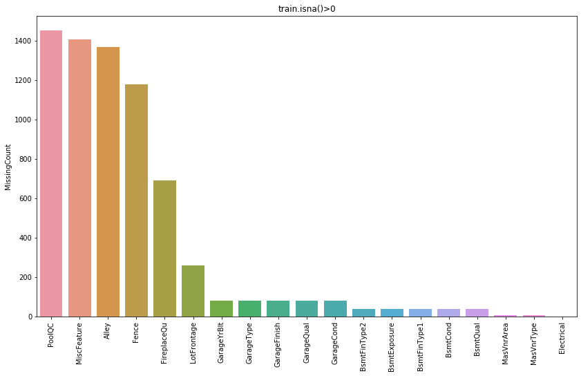

```python
plt.figure(figsize=(14,8))
Missing1=train[train.columns[train.isnull().sum()>0]].isnull().sum().sort_values(ascending=False).to_frame()
Missing1.columns = ['MissingCount']
Missing1['MissingCount']
p1=sns.barplot(x=Missing1.index, y='MissingCount', data=Missing1)
p1.set_xticklabels(p1.get_xticklabels(), rotation=90)
p1.set_title('train.isna()>0')
```

We are going to assume that for some the missing values like those in PoolQC are because there is no pool present for the house in question. Therefore we will set these values to none.

Sometimes the mode will be based on houses with similar features such as those form the same Neighborhood, yearbuilt, or has Central Air as a way to make a more educated guess at what the value might be.

```python
print('PoolQC:',Counter(train['PoolQC']))
train['PoolQC'].fillna('None',inplace=True)

print('\nAlley:',Counter(train['Alley']))
train['Alley'].fillna('None',inplace=True)

print('\nMiscFeature:',Counter(train['MiscFeature']))
train['MiscFeature'].fillna('None',inplace=True)

print('\nFence:',Counter(train['Fence']))
train['Fence'].fillna('None',inplace=True)

print('\nFireplaceQu',Counter(train['FireplaceQu']))
print('FirePlaces',Counter(train['Fireplaces']))
train['FireplaceQu'].fillna('None',inplace=True)#Compare with Fireplaces we will set nan=None since they will match at 690 each
```

```
PoolQC: Counter({nan: 1453, 'Gd': 3, 'Ex': 2, 'Fa': 2})

Alley: Counter({nan: 1369, 'Grvl': 50, 'Pave': 41})

MiscFeature: Counter({nan: 1406, 'Shed': 49, 'Gar2': 2, 'Othr': 2, 'TenC': 1})

Fence: Counter({nan: 1179, 'MnPrv': 157, 'GdPrv': 59, 'GdWo': 54, 'MnWw': 11})

FireplaceQu Counter({nan: 690, 'Gd': 380, 'TA': 313, 'Fa': 33, 'Ex': 24, 'Po': 20})
FirePlaces Counter({0: 690, 1: 650, 2: 115, 3: 5})
```

## Now to figure out the best mode for LotFrontage

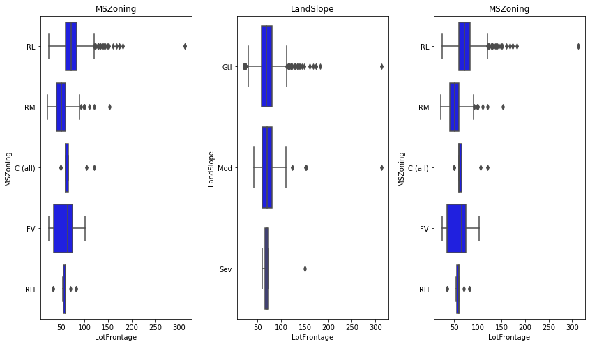

```python
plt.figure(figsize=(14,8))

plt.subplot(1, 3, 1)
p1=sns.boxplot(y=train['MSZoning'], data=train,color='Blue',x=train['LotFrontage']).set_title('MSZoning')


plt.subplot(1, 3, 2)
p2=sns.boxplot(y=train['LandSlope'], data=train,color='Blue',x=train['LotFrontage']).set_title('LandSlope')


plt.subplot(1, 3, 3)
p3=sns.boxplot(y=train['MSZoning'], data=train,color='Blue',x=train['LotFrontage']).set_title('MSZoning')

plt.subplots_adjust(wspace=0.3)
```

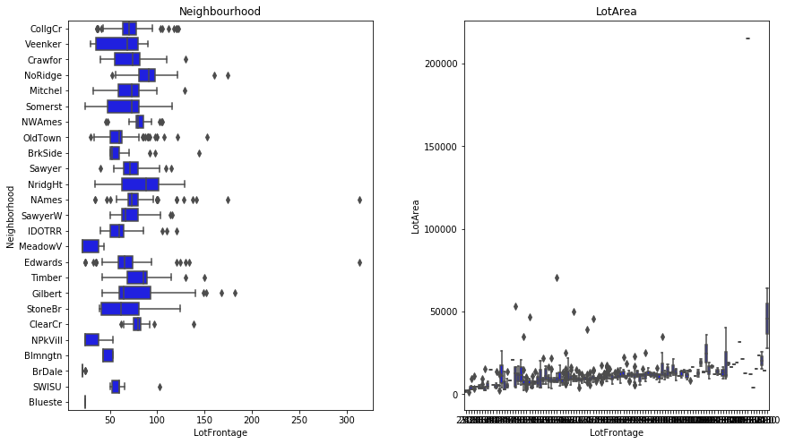

```python
plt.figure(figsize=(14,8))

plt.subplot(1, 2, 1)
p1=sns.boxplot(y=train['Neighborhood'], data=train,color='Blue',x=train['LotFrontage']).set_title('Neighbourhood')


plt.subplot(1, 2, 2)
p2=sns.boxplot(y=train['LotArea'], data=train,color='Blue',x=train['LotFrontage']).set_title('LotArea')

plt.subplots_adjust(wspace=0.3)
```

### We will take the median based on Neighborhood

```python
train['LotFrontage'] = train.groupby("Neighborhood")["LotFrontage"].transform(
    lambda x: x.fillna(x.median()))
```

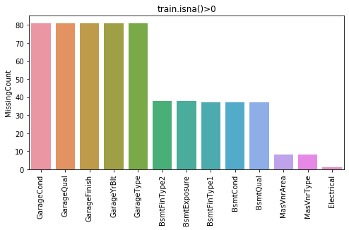

```python
plt.figure(figsize=(8,4))
Missing1=train[train.columns[train.isnull().sum()>0]].isnull().sum().sort_values(ascending=False).to_frame()
Missing1.columns = ['MissingCount']
Missing1['MissingCount']
p1=sns.barplot(x=Missing1.index, y='MissingCount', data=Missing1)
p1.set_xticklabels(p1.get_xticklabels(), rotation=90)
p1.set_title('train.isna()>0')
```

```python
#Assume no Garage is pressent
train['GarageCond'].fillna('None',inplace=True)
train['GarageQual'].fillna('None',inplace=True)
train['GarageFinish'].fillna('None',inplace=True)
train['GarageYrBlt'].fillna(0,inplace=True)
train['GarageType'].fillna('None',inplace=True)

#Assume no Basement is pressent
train['BsmtFinType2'].fillna('None',inplace=True)
train['BsmtExposure'].fillna('None',inplace=True)
train['BsmtFinType1'].fillna('None',inplace=True)
train['BsmtCond'].fillna('None',inplace=True)
train['BsmtQual'].fillna('None',inplace=True)

#Assume no Masonry
train['MasVnrArea'].fillna(0,inplace=True)
train['MasVnrType'].fillna('None',inplace=True)
```

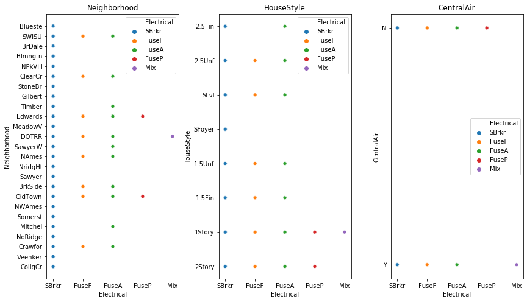

```python
plt.figure(figsize=(14,8))

plt.subplot(1, 3, 1)
p1=sns.scatterplot(y=train['Neighborhood'], data=train,color='yellow',x=train['Electrical'],hue='Electrical').set_title('Neighborhood')



plt.subplot(1, 3, 2)
p2=sns.scatterplot(y=train['HouseStyle'], data=train,color='yellow',x=train['Electrical'],hue='Electrical').set_title('HouseStyle')



plt.subplot(1, 3, 3)
p3=sns.scatterplot(y=train['CentralAir'], data=train,color='yellow',x=train['Electrical'],hue='Electrical').set_title('CentralAir')


plt.subplots_adjust(wspace=0.3)
```

```python
train.index[train['Electrical'].isna()].tolist()
```

```
[1379]
```

```python
i=0
while i<len(train.iloc[1379].tolist()):
    print(train.iloc[1379].index.tolist()[i],train.iloc[1379].tolist()[i])
    i+=1
```

```
MSSubClass 80
MSZoning RL
LotFrontage 73.0
LotArea 9735
Street Pave
Alley None
LotShape Reg
LandContour Lvl
Utilities AllPub
LotConfig Inside
LandSlope Gtl
Neighborhood Timber
Condition1 Norm
Condition2 Norm
BldgType 1Fam
HouseStyle SLvl
OverallQual 5
OverallCond 5
YearBuilt 2006
YearRemodAdd 2007
RoofStyle Gable
RoofMatl CompShg
Exterior1st VinylSd
Exterior2nd VinylSd
MasVnrType None
MasVnrArea 0.0
ExterQual TA
ExterCond TA
Foundation PConc
BsmtQual Gd
BsmtCond TA
BsmtExposure No
BsmtFinType1 Unf
BsmtFinSF1 0
BsmtFinType2 Unf
BsmtFinSF2 0
BsmtUnfSF 384
TotalBsmtSF 384
Heating GasA
HeatingQC Gd
```

[output cut: 25 more lines]

```
WoodDeckSF 100
OpenPorchSF 0
EnclosedPorch 0
3SsnPorch 0
ScreenPorch 0
PoolArea 0
PoolQC None
Fence None
MiscFeature None
MiscVal 0
MoSold 5
YrSold 2008
SaleType WD
SaleCondition Normal
SalePrice 167500
```

```python
#Based on the info above we will set it equal to SBrkr
train['Electrical'].fillna('SBrkr',inplace=True)
```

```python
train.isna().sum().sum()
```

```
0
```

# We have filled all nan Values in train now for Test

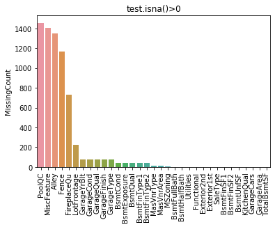

```python
Missing2=test[test.columns[test.isnull().sum()>0]].isnull().sum().sort_values(ascending=False).to_frame()
Missing2.columns = ['MissingCount']
Missing2['MissingCount']
p2=sns.barplot(x=Missing2.index, y='MissingCount', data=Missing2)
p2.set_xticklabels(p2.get_xticklabels(), rotation=90)
p2.set_title('test.isna()>0')
```

### We will use the same method as for train

```python
test['PoolQC'].fillna('None',inplace=True)
test['Alley'].fillna('None',inplace=True)
test['MiscFeature'].fillna('None',inplace=True)
test['Fence'].fillna('None',inplace=True)
test['FireplaceQu'].fillna('None',inplace=True)

test['LotFrontage'] = train.groupby("Neighborhood")["LotFrontage"].transform(
    lambda x: x.fillna(x.median()))

test['GarageCond'].fillna('None',inplace=True)
test['GarageQual'].fillna('None',inplace=True)
test['GarageFinish'].fillna('None',inplace=True)
test['GarageYrBlt'].fillna(0,inplace=True)
test['GarageType'].fillna('None',inplace=True)

test['BsmtFinType2'].fillna('None',inplace=True)
test['BsmtExposure'].fillna('None',inplace=True)
test['BsmtFinType1'].fillna('None',inplace=True)
test['BsmtCond'].fillna('None',inplace=True)
test['BsmtQual'].fillna('None',inplace=True)

test['MasVnrArea'].fillna(0,inplace=True)
test['MasVnrType'].fillna('None',inplace=True)
test['Electrical'].fillna('SBrkr',inplace=True)

test['MSZoning'].fillna(test['MSZoning'].mode()[0],inplace=True)
test['Functional'].fillna(test['Functional'].mode()[0],inplace=True)
test['BsmtFullBath'].fillna(test['BsmtFullBath'].mode()[0],inplace=True)
test['BsmtHalfBath'].fillna(test['BsmtHalfBath'].mode()[0],inplace=True)

test['Utilities'].fillna(test['Utilities'].mode()[0],inplace=True)
test['GarageArea'].fillna(0,inplace=True)
test['GarageCars'].fillna(0,inplace=True)
test['BsmtFinSF1'].fillna(0,inplace=True)
test['BsmtFinSF2'].fillna(0,inplace=True)
test['BsmtUnfSF'].fillna(0,inplace=True)
test['TotalBsmtSF'].fillna(0,inplace=True)


test['SaleType'].fillna(test['SaleType'].mode()[0],inplace=True)

test['KitchenQual'] = train.groupby("Neighborhood")["KitchenQual"].transform(
    lambda x: x.fillna(x.mode()))
test['Exterior2nd'] = train.groupby("Neighborhood")["Exterior2nd"].transform(
    lambda x: x.fillna(x.mode()))
test['Exterior1st'] = train.groupby("Neighborhood")["Exterior1st"].transform(
    lambda x: x.fillna(x.mode()))

#for i in Missing:
 #   test[i].fillna('none',inplace=True)
```

```python
test.isna().sum().sum() # no missing values in test
```

```
0
```

### We have now replace all nan Values

### Next we will assign dummie Varibles to all catagorical variables

```python
#to ensure both dataframes have same number of dummie columns we will combine them using istrain to seperate them
train['istrain']=1
test['istrain']=0
combined=pd.concat([train,test])
combined.iloc[np.r_[0:5, -5:0]]
```

|  | 1stFlrSF | 2ndFlrSF | 3SsnPorch | Alley | BedroomAbvGr | BldgType | BsmtCond | BsmtExposure | BsmtFinSF1 | BsmtFinSF2 | ... | ScreenPorch | Street | TotRmsAbvGrd | TotalBsmtSF | Utilities | WoodDeckSF | YearBuilt | YearRemodAdd | YrSold | istrain |
| --- | --- | --- | --- | --- | --- | --- | --- | --- | --- | --- | --- | --- | --- | --- | --- | --- | --- | --- | --- | --- | --- |
| 0 | 856 | 854 | 0 | None | 3 | 1Fam | TA | No | 706.0 | 0.0 | ... | 0 | Pave | 8 | 856.0 | AllPub | 0 | 2003 | 2003 | 2008 | 1 |
| 1 | 1262 | 0 | 0 | None | 3 | 1Fam | TA | Gd | 978.0 | 0.0 | ... | 0 | Pave | 6 | 1262.0 | AllPub | 298 | 1976 | 1976 | 2007 | 1 |
| 2 | 920 | 866 | 0 | None | 3 | 1Fam | TA | Mn | 486.0 | 0.0 | ... | 0 | Pave | 6 | 920.0 | AllPub | 0 | 2001 | 2002 | 2008 | 1 |
| 3 | 961 | 756 | 0 | None | 3 | 1Fam | Gd | No | 216.0 | 0.0 | ... | 0 | Pave | 7 | 756.0 | AllPub | 0 | 1915 | 1970 | 2006 | 1 |
| 4 | 1145 | 1053 | 0 | None | 4 | 1Fam | TA | Av | 655.0 | 0.0 | ... | 0 | Pave | 9 | 1145.0 | AllPub | 192 | 2000 | 2000 | 2008 | 1 |
| 1454 | 546 | 546 | 0 | None | 3 | Twnhs | TA | No | 0.0 | 0.0 | ... | 0 | Pave | 5 | 546.0 | AllPub | 0 | 1970 | 1970 | 2006 | 0 |
| 1455 | 546 | 546 | 0 | None | 3 | TwnhsE | TA | No | 252.0 | 0.0 | ... | 0 | Pave | 6 | 546.0 | AllPub | 0 | 1970 | 1970 | 2006 | 0 |
| 1456 | 1224 | 0 | 0 | None | 4 | 1Fam | TA | No | 1224.0 | 0.0 | ... | 0 | Pave | 7 | 1224.0 | AllPub | 474 | 1960 | 1996 | 2006 | 0 |
| 1457 | 970 | 0 | 0 | None | 3 | 1Fam | TA | Av | 337.0 | 0.0 | ... | 0 | Pave | 6 | 912.0 | AllPub | 80 | 1992 | 1992 | 2006 | 0 |
| 1458 | 996 | 1004 | 0 | None | 3 | 1Fam | TA | Av | 758.0 | 0.0 | ... | 0 | Pave | 9 | 996.0 | AllPub | 190 | 1993 | 1994 | 2006 | 0 |

10 rows × 81 columns

```python
dummies=pd.get_dummies(combined,columns=combined.select_dtypes(exclude=['int64','float']).columns.tolist(),drop_first=False)
dummies.iloc[np.r_[0:5, -5:0]]

train_WDummies=dummies[dummies['istrain']==1]
test_WDummies=dummies[dummies['istrain']==0]

train_WDummies.shape#(1460, 334)
test_WDummies.shape #(1459, 334)
```

```
(1459, 334)
```

## Now lets do some randomforest regression

```python
from sklearn.ensemble import RandomForestClassifier
rfc = RandomForestClassifier(n_estimators=400)


from sklearn.model_selection import train_test_split

y=(train_WDummies['SalePrice'].astype('float32'))
y=(np.log(y)*1000000).astype('int32')#controll sigfigs of y after log transformation

x=train_WDummies.drop(['SalePrice'],axis=1)
```

```python
#train test split
x_train, x_test, y_train, y_test = train_test_split(x, y, test_size=0.30, random_state=101)
rfc.fit(x_train,y_train)
```

```
RandomForestClassifier(bootstrap=True, class_weight=None, criterion='gini',
                       max_depth=None, max_features='auto', max_leaf_nodes=None,
                       min_impurity_decrease=0.0, min_impurity_split=None,
                       min_samples_leaf=1, min_samples_split=2,
                       min_weight_fraction_leaf=0.0, n_estimators=400,
                       n_jobs=None, oob_score=False, random_state=None,
                       verbose=0, warm_start=False)
```

```python
predictions = rfc.predict(x_test)
```

```python
from sklearn.metrics import classification_report,confusion_matrix

 #print(classification_report(y_test,predictions)) #takes up to much space when printed
```

```python
print(confusion_matrix(y_test,predictions))
```

```
[[0 0 0 ... 0 0 0]
 [0 0 0 ... 0 0 0]
 [0 0 0 ... 0 0 0]
 ...
 [0 0 0 ... 0 0 0]
 [0 0 0 ... 0 0 0]
 [0 0 0 ... 0 1 0]]
```

```python
TestValues=test_WDummies.drop(['SalePrice'],axis=1)
randForest_pred=rfc.predict((TestValues))
##expmq1 is opposite of log1p
submissionRF=pd.DataFrame({'Id':test_index,'SalePrice':np.expm1(randForest_pred/1000000)})
filename = 'SalePrice Predictions RandomForest.csv'
submissionRF.to_csv(filename,index=False)
print('Saved file: ' + filename)
```

```
Saved file: SalePrice Predictions RandomForest.csv
```

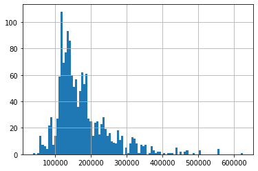

```python
submissionRF['SalePrice'].hist(bins=100)
```

```python
submissionRF.iloc[np.r_[0:5, -5:0]]
```

|  | Id | SalePrice |
| --- | --- | --- |
| 0 | 1461 | 128998.911849 |
| 1 | 1462 | 151498.863054 |
| 2 | 1463 | 172998.848888 |
| 3 | 1464 | 172998.848888 |
| 4 | 1465 | 200998.962405 |
| 1454 | 2915 | 80998.964874 |
| 1455 | 2916 | 87998.903776 |
| 1456 | 2917 | 159998.984925 |
| 1457 | 2918 | 84499.015772 |
| 1458 | 2919 | 214998.933971 |

### Now we will use XGBoost

```python
y=(train_WDummies['SalePrice'].astype('float32'))
y=((np.log1p(y).astype('float32'))*1000000)
x=train_WDummies.drop(['SalePrice'],axis=1)
xtest=test_WDummies.drop(['SalePrice'],axis=1)
xgb = XGB.XGBRegressor(colsample_bytree=0.8, subsample=0.5,
                             learning_rate=0.05, max_depth=3,
                             min_child_weight=1.2, n_estimators=2000,
                             reg_alpha=0.1, reg_lambda=0.3, gamma=0.01,
                             silent=1, random_state =7, nthread = -1)


xgb.fit(x, y)
xgb_pred = xgb.predict(xtest)
```

```python
submission_xgboost=pd.DataFrame({'Id':test_index,'SalePrice':np.expm1(xgb_pred/1000000)})
filename = 'SalePrice Predictions with XGBoost.csv'
submission_xgboost.to_csv(filename,index=False)
print('Saved file: ' + filename)
```

```
Saved file: SalePrice Predictions with XGBoost.csv
```

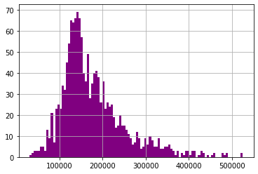

```python
submission_xgboost['SalePrice'].hist(bins=100,color='purple')
```

```python
submission_xgboost.iloc[np.r_[0:5, -5:0]]
```

|  | Id | SalePrice |
| --- | --- | --- |
| 0 | 1461 | 128759.838821 |
| 1 | 1462 | 165200.628869 |
| 2 | 1463 | 191163.960152 |
| 3 | 1464 | 196637.048397 |
| 4 | 1465 | 187158.037068 |
| 1454 | 2915 | 80950.379472 |
| 1455 | 2916 | 75069.879032 |
| 1456 | 2917 | 160236.440933 |
| 1457 | 2918 | 112819.348920 |
| 1458 | 2919 | 231065.308940 |

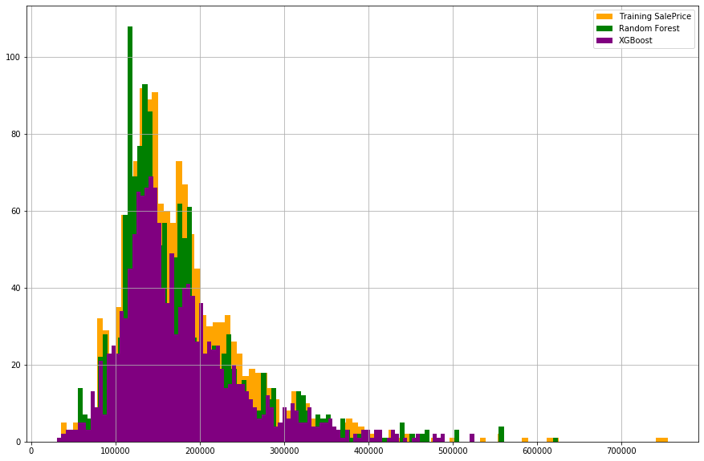

```python
plt.figure(figsize=(15, 10))
train['SalePrice'].hist(bins=100,color='orange', label='Training SalePrice')
submissionRF['SalePrice'].hist(bins=100,color='green',label='Random Forest')
submission_xgboost['SalePrice'].hist(bins=100,color='purple',label='XGBoost')
plt.legend()
```

## It looks like we have over fit our Random forest to the training data

### To take this further we could

#### Try blending our random forest and XGBoost to prevent over fitting and make our model better

#### We Could also look for outliers and remove them or replace the values with something less extreme

#### We could also look at our variables more closely when filling our missing values

# The End

### Lets get a deeper look at the data

```python
train = pd.read_csv("train.csv",index_col='Id')#reload original data
```

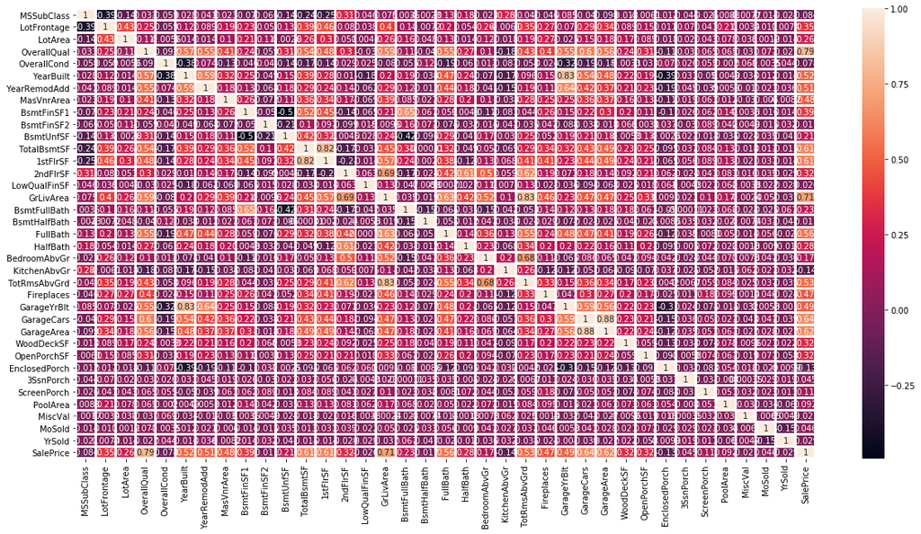

```python
plt.figure(figsize=(20, 10))
sns.heatmap(train.corr() ,linecolor='white',linewidths=2,annot=True)
```

### Now we will select the values with the highest correlation to get a better look

```
['SalePrice',
 'OverallQual',
 'GrLivArea',
 'GarageCars',
 'GarageArea',
 'TotalBsmtSF',
 '1stFlrSF',
 'FullBath',
 'TotRmsAbvGrd',
 'YearBuilt',
 'YearRemodAdd']
```

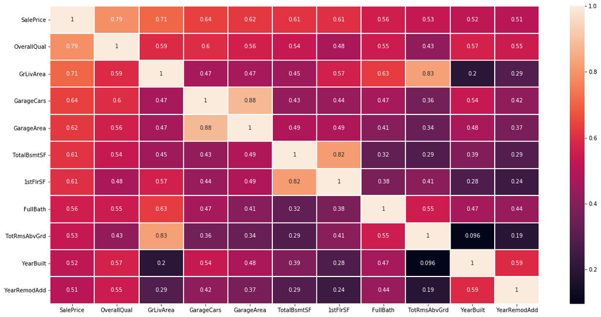

```python
top10cor=abs(abs(train.corr())).nlargest(11,columns='SalePrice')

plt.figure(figsize=(20, 10))
sns.heatmap(train[top10cor.index].corr(), linecolor='white',linewidth=1,annot=True)
list(top10cor.index)
```

### Lets look for some correlation between our missing values

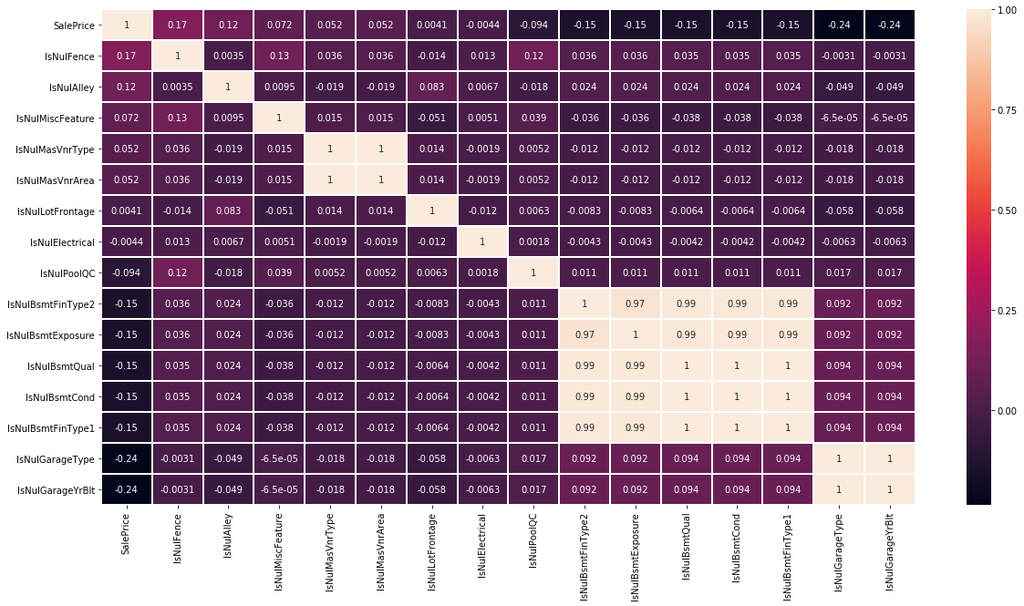

```python
#lets create a new data frame for our IsnNull table

IsNulldf = pd.DataFrame(columns='IsNul'+train.columns)
IsNulldf['IsNul'+train.columns]=train[train.columns].isnull()
IsNulldf['SalePrice']=train['SalePrice']
IsNulldf.head()

plt.figure(figsize=(20, 10))
sns.heatmap(IsNulldf[IsNulldf.corr().nlargest(16,columns='SalePrice').index].corr(), linecolor='white',linewidth=1,annot=True)
```

### We can see the correlation between similar variables like those relating to garage or basement

```python
def boxstats(data):
    '''Returns a prineted out summary of boxplot stats including max, min, mean, whisker values, nearest data points inside
        whiskers and number of data pointsouside the whisker values

        Call boxstatsarr() to get values returned in array form] '''
    values=data.sort_values()
    minimum=values.iloc[0] ###### we must use iloc or else it uses the original index from the df and .sort would do nothing
    maximum=values.iloc[(len(values)-1)]
    Q1=values.iloc[int((0.25*len(values)))]#must cast to an int or: Cannot index by location index with a non-integer key
    Q2=values.iloc[int(0.50*len(values))]
    Q3=values.iloc[int(0.75*len(values))]
    LW=int(Q1-1.5*(Q3-Q1))#2-1  must select nearest point within this range to properly set whisker !!!!!!!!!!!
    UW=int(Q3+1.5*(Q3-Q1))#3-2
    LWP=values.array[np.searchsorted(values, LW, side='Left')]
    UWP=values.array[np.searchsorted(values, UW, side='Right')-1]# is left correct?
   # indexmax=[np.searchsorted(values, UW, side='Left')-1]
#abs(data-LW).argmin
    #LWf = np.abs(values - LW).argmin()
    tolow=int((np.searchsorted(values, LW, side='Left')))
    tohigh=int(len(values)-(np.searchsorted(values, UW, side='Right')))

    mean=int(sum(values)/len(values))#this includes our outliers in the mean
    nullcount=data.isnull().sum()
    dist=data.nunique()
    print('min {} \nL-whisker: {} \nLowestinsidewhisker: {} \nQ1  {} \nQ2  {} \nQ3  {} \nmax {}\nU-whisker is {} \nhighestsinsidewhisker is {}\nmean is {}\nwe have {} values below whiskers and {} above \nThere are {} null values \nthere are {} distinct values'.format(minimum,LW,LWP,Q1,Q2,Q3,maximum,UW,UWP,mean,tolow,tohigh,nullcount,dist))
    #return [LW,minimum,Q1,Q2,Q3,maximum,UW]
   # argmin()
```

```python
def QuickJab(whatdata,ylab):
    '''QuickLook(whatdata,ylab):  sns.boxplot(y=whatdata,color='Yellow')
    returns yellow boxplot with black swarmoverlay

    example: QuickJab(train['SalePrice'],'SalePrice')

  '''
    sns.boxplot(y=whatdata,color='Yellow')
    #ax=sns.swarmplot(y=whatdata,color='black')
    ax=sns.violinplot(y=whatdata,color='black') #use violin plot as swarm plot it to intensive
    ax.set_ylabel(ylab,fontsize=40)
    boxstats(whatdata)
```

```python
def boxstatsarr(data):
    '''Returns array summary of boxplot values [LW,minimum,Q1,Q2,Q3,maximum,UW)]

     Returns a prineted out summary of boxplot stats including max, min, mean, whisker values, nearest data points inside
        whiskers and number of data pointsouside the whisker values

        Call boxstats() to get printed summary of stats] '''

    values=train[train['YearBuilt']==1880]['SalePrice']
    values=data.sort_values()
    minimum=int(values.iloc[0]) #we must use iloc or else it uses the original index from the df and .sort would do nothing
    maximum=values.iloc[(len(values)-1)]
    Q1=values.iloc[int((0.25*len(values)))]#must cast to an int or: Cannot index by location index with a non-integer key
    Q2=values.iloc[int(0.50*len(values))]
    Q3=values.iloc[int(0.75*len(values))]
    LW=int(Q1-1.5*(Q3-Q1))#2-1  must select nearest point within this range to properly set whisker !!!!!!!!!!!
    UW=int(Q3+1.5*(Q3-Q1))#3-2

                                                                    #numpy.searchsorted(a, v, side='left', sorter=None)
                                                                    #Find the indices into a sorted array a such that, if the
                                                                    #corresponding elements in v were# inserted before the
                                                                    #indices, the order of a would be preserved.
    LWP=values.array[np.searchsorted(values, LW, side='Left')]     ##note ##side	returned index i satisfies
    UWP=values.array[np.searchsorted(values, UW, side='Right')-1]     #left	a[i-1] < v <= a[i]
                                                                        #right	a[i-1] <= v < a[i]
    mean=int(sum(values)/len(values))

    tolow=int((np.searchsorted(values, LW, side='Left')))
    tohigh=int(len(values)-(np.searchsorted(values, UW, side='Right')))

#abs(data-LW).argmin
    #LWf = np.abs(values - LW).argmin()


    #if you're going to perform arithmetic functions to your lists, you should really be using arrays instead.
    from numpy import array
    boxstatarr=array([minimum,LW,LWP,Q1,Q2,Q3,maximum,UW,UWP,mean,tolow,tohigh])
    return boxstatarr
```

```
min 1872
L-whisker: 1885
Lowestinsidewhisker: 1885
Q1  1954
Q2  1973
Q3  2000
max 2010
U-whisker is 2069
highestsinsidewhisker is 2010
mean is 1971
we have 7 values below whiskers and 0 above
There are 0 null values
there are 112 distinct values
```

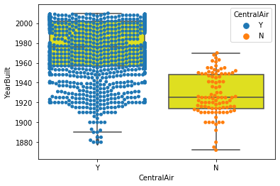

```python
#lets check for every year
sns.boxplot(y=train['YearBuilt'], data=train,color='yellow',x=train['CentralAir'])
sns.swarmplot(y=train['YearBuilt'],x=train['CentralAir'], data=train,hue='CentralAir',split=False)#swarmplot
boxstats(train['YearBuilt'])
```

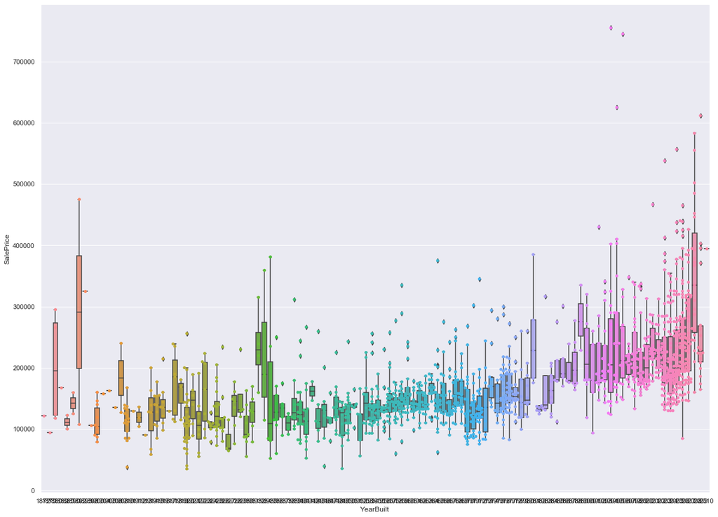

```python
sns.set(rc={'figure.figsize':(20,15)})
sns.boxplot(x='YearBuilt',y='SalePrice', data=train)
plt=sns.swarmplot(x='YearBuilt',y='SalePrice', data=train)
```

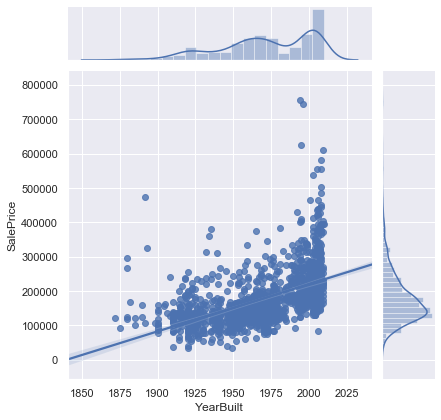

```python
sns.jointplot(x='YearBuilt',y='SalePrice',data=train,kind='reg')
```

### We can see the correlation between sales price and the year the house was built as expected

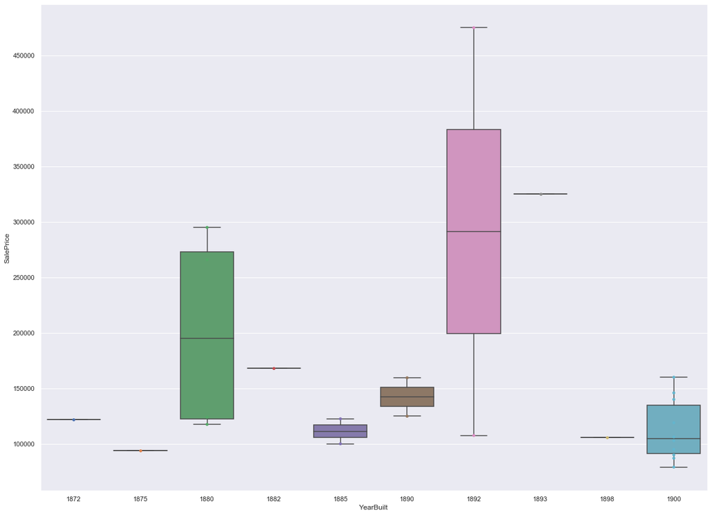

```python
sns.boxplot(x=train[train['YearBuilt']<1901]['YearBuilt'],y=train[train['YearBuilt']<1901]['SalePrice'], data=train)
sns.swarmplot(x=train[train['YearBuilt']<1901]['YearBuilt'],y=train[train['YearBuilt']<1901]['SalePrice'], data=train)
```

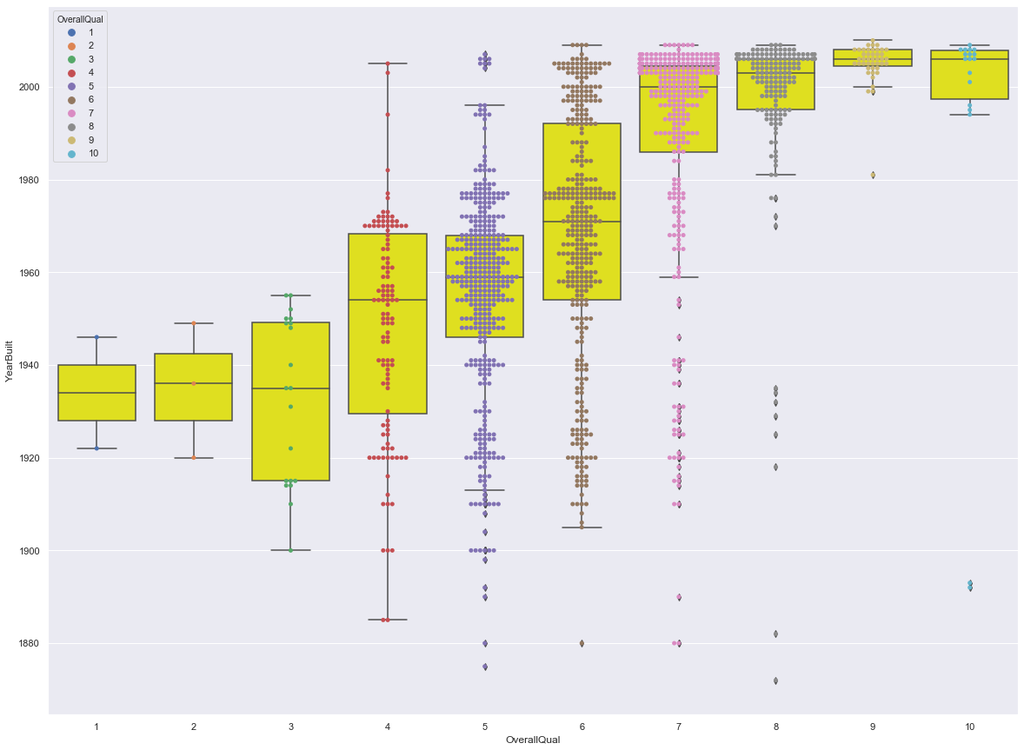

```python
#lets check for  year
sns.boxplot(y=train['YearBuilt'], data=train,color='yellow',x=train['OverallQual'])
sns.swarmplot(y=train['YearBuilt'],x=train['OverallQual'], data=train,hue='OverallQual',split=False)#swarmplot
```